# article

**Microbial Bio-inoculation Effects on Seed Germination Dynamics and Field Performance of Pea (*Pisum sativum* L.) under Osmotic Stress and Fertilization**

Francisco Guevara-Fernández1*; Sebastian Casas-Niño2; Milagros Ninoska Munoz-Salas3; Wagner Meza-Maicelo1,4,5; Manuel Oliva-Cruz1,4; Flavio Lozano-Isla1,4,5*.

1 Instituto de Investigación para el Desarrollo Sustentable de Ceja de Selva (INDES-CES), Universidad Nacional Toribio Rodríguez de Mendoza de Amazonas (UNTRM), Chachapoyas - Amazonas 01001, Perú.

2 Dirección de Servicios Estratégicos Agrarios - Estación Experimental Agraria El Chira, Instituto Nacional de Innovación Agraria (INIA), Piura 20120, Perú.

3 Department of Earth and Environment, Institute of Environment, Florida International University, Miami, FL 33199, USA

4 Facultad de Ingeniería y Ciencias Agrarias, Universidad Nacional Toribio Rodríguez de Mendoza de Amazonas (UNTRM), Chachapoyas - Amazonas 01001, Perú.

5 Centro de Investigación e Innovación en Granos y Semillas, Universidad Nacional Toribio Rodríguez de Mendoza de Amazonas (UNTRM), Chachapoyas - Amazonas 01001, Perú.

* Corresponding author: flavio.lozano@untrm.edu.pe

| Author | ORCID | email |
| --- | --- | --- |
| **Francisco Guevara-Fernández** | 0000-0002-9967-6590 | elen.guevara@untrm.edu.pe |
| **Sebastian Casas-Niño** | 0000-0002-6576-8761 | 20140231@lamolina.edu.pe |
| **Milagros Ninoska Munoz-Salas** | 0009-0001-7278-5690 | mmuno126@fiu.edu |
| **Wagner Meza Maicelo** | 0009-0003-3556-3866 | wagner.meza.epg@untrm.edu.pe |
| **Manuel Oliva-Cruz** | 0000-0002-9670-0970 | manuel.oliva@untrm.edu.pe |
| **Flavio Lozano-Isla** | 0000-0002-0714-669X | flavio.lozano@untrm.edu.pe |

**ABSTRACT**

Microbial bio-inoculants have been proposed as management tools to enhance crop performance under variable environmental conditions; however, their effectiveness is frequently modulated by site-specific factors. This study evaluated the effects of bio-inoculation on seed germination and seedling vigor of pea under osmotic stress induced by polyethylene glycol (PEG 6000), and assessed the interaction between bio-inoculation and two fertilization levels under field conditions in the Amazonas region of Peru. Under laboratory conditions, germination percentage remained high across all treatments (93.3–100%) and was not affected by bio-inoculation or osmotic potential. In contrast, osmotic stress significantly altered germination dynamics. Mean germination time increased from 1.85–2.09 days at 0 MPa to 2.26–2.43 days at −0.8 MPa, while germination synchrony and seedling vigor declined with increasing stress. The seedling vigor index reached maximum values at −0.2 MPa (4.47–5.29) and decreased at −0.8 MPa (1.50–2.00). Multivariate analyses indicated that variation in germination responses was mainly associated with germination timing and vigor rather than seed viability. Field experiments revealed variability in agronomic traits between locations. Plant height ranged from 38.5–46.3 cm in Lamud and from 100.6–108.3 cm in Molinopampa, while grain yield varied from 698–1846 kg/ha and 8771–9919 kg/ha, respectively. Yield variation was explained by pod weight and number of pods per plant. Environmental conditions showed a stronger influence than microbial bio-inoculation on germination dynamics and field productivity, although positive trends associated with bio-inoculant application were observed.

**Keywords:** abiotic stress; andean-amazonian region; germination indices; multilocation trial; plant growth-promoting bacteria

**INTRODUCTION**

Pea (*Pisum sativum* L.) is one of the most widely cultivated cool-season grain legumes, valued for its high protein content, contribution to human nutrition, and capacity to enhance soil fertility through biological nitrogen fixation [[1,2]](https://www.zotero.org/google-docs/?Vv36Fb). Globally, peas rank among one of the most important pulse crops and are widely integrated into sustainable cropping systems due to their relatively low input requirements and compatibility with cereal-based rotations [[3]](https://www.zotero.org/google-docs/?0QpVaS). In developing regions, including the Andean and Amazonian zones of South America, pea production plays a key role in food security and smallholder livelihoods, yet yields remain highly vulnerable to environmental stressors and suboptimal nutrient management [[4]](https://www.zotero.org/google-docs/?awNn6G).

Among abiotic constraints, water limitation is one of the most critical factors affecting legume establishment, early seedling growth, and final yield [[5–8]](https://www.zotero.org/google-docs/?hsJ3Wq). Climate change projections indicate an increasing frequency and intensity of drought events, particularly in rainfed agricultural systems, thereby exacerbating climatic risk during sensitive phenological stages such as germination and early vegetative development [[9,10]](https://www.zotero.org/google-docs/?0XzuSs). In peas and other legumes, drought stress impairs germination kinetics and delays seedling emergence, reduces biomass accumulation, and ultimately limits yield formation through constraints on water uptake and early growth processes, while concurrently restricting enzymatic activity, carbon assimilation, and overall photosynthetic efficiency [[2,11]](https://www.zotero.org/google-docs/?OQCcZd). Controlled osmotic stress induced by polyethylene glycol (PEG) has therefore been widely adopted as a reliable experimental approach to simulate drought conditions during germination, allowing precise assessment of seed physiological responses under reduced water potential [[12,13]](https://www.zotero.org/google-docs/?kXypdg).

In parallel with water availability, nutrient management – particularly nitrogen fertilization – remains a major determinant of pea productivity. Although peas possess symbiotic nitrogen-fixing capacity, mineral nitrogen inputs are often required to support early growth and maximize yield, especially under stress conditions or in soils with limited biological activity [[14]](https://www.zotero.org/google-docs/?cE8sIo). However, excessive fertilization increases production costs and environmental impacts, while drought conditions can further reduce nutrient use efficiency by limiting root activity and nutrient uptake [[15–17]](https://www.zotero.org/google-docs/?1hC6U5). Consequently, strategies that improve plant resilience while reducing dependence on full fertilizer doses are increasingly prioritized in sustainable legume production systems.

Another major limitation in pea-based systems is the continued reliance on synthetic fertilizers. Although mineral nitrogen (N) and phosphorus (P) inputs can enhance productivity, excessive fertilizer use contributes to soil acidification, nutrient imbalances, and negative environmental externalities, including eutrophication and greenhouse gas emissions [[18,19]](https://www.zotero.org/google-docs/?gKcD65). Sustainable intensification therefore requires management practices that improve nutrient-use efficiency while enabling partial substitution of chemical fertilizers without yield penalties. In this context, bio-inoculation with plant growth-promoting microorganisms (PGPM), including *Bacillus, Azospirillum,* and *Trichoderma* spp. has emerged as a promising strategy [[20–22]](https://www.zotero.org/google-docs/?nAGDCo). These microorganisms promote crop growth through multiple mechanisms, such as phytohormone production, biological nitrogen fixation, nutrient solubilization, and stress mitigation mediated by 1-aminocyclopropane-1-carboxylate (ACC) deaminase activity and improved osmotic adjustment [[23,24]](https://www.zotero.org/google-docs/?q6dbI9).

Recent studies indicate that co-application of microbial inoculants with reduced fertilizer rates can sustain or even enhance legume yields while simultaneously improving soil microbial diversity and resilience to environmental stress [[25–27]](https://www.zotero.org/google-docs/?yWiSpe). In pea, inoculation with *Bacillus, Azospirillum,* and *Trichoderma* spp. has been associated with improvements in germination, nodulation, nutrient uptake, and stress tolerance through modulation of root architecture and enhanced rhizosphere interaction [[28,29]](https://www.zotero.org/google-docs/?ilChpY). Beyond direct plant growth promotion, microbial inoculants contribute to soil ecological stability by stimulating beneficial microbial consortia and increasing enzyme activities linked to nitrogen and phosphorus cycling [[30,31]](https://www.zotero.org/google-docs/?uJXv8S). In particular, *Bacillus* spp. have been shown to alleviate drought stress through ACC deaminase activity, proline accumulation, and osmolyte production, thereby improving seedling establishment under water-limited conditions [[32,33]](https://www.zotero.org/google-docs/?sNFZlr).

Despite growing evidence of microbial benefits under controlled conditions, results from field studies remain inconsistent, particularly when bio-inoculation is combined with varying fertilization regimes [[34–36]](https://www.zotero.org/google-docs/?kT8Muo). While some studies report improved emergence, growth, and yield under reduced fertilizer inputs, others suggest that favorable environmental conditions may mask microbial effects, especially during germination when water availability is tightly regulated [[9,37]](https://www.zotero.org/google-docs/?EcXUgr). Moreover, most studies focus either on laboratory-based germination assays or on field performance, with limited integration of both scales within a single experimental framework. This gap constrains the translation of early physiological responses into agronomically meaningful outcomes.

In the Amazonian region of Peru, where climatic variability, episodic water stress, and heterogeneous soil fertility frequently constrain legume production, integrated evaluations of bio-inoculation under both controlled and field conditions are particularly relevant. Assessing whether microbial inoculants can enhance drought resilience during early development and support yield formation under reduced fertilization offers a promising pathway toward more resilient and resource-efficient pea-based production systems.

Therefore, the objectives of this study were: (i) to evaluate the effects of bio-inoculation on pea seed germination and seedling biomass under simulated drought stress induced by PEG 6000 under controlled conditions, and (ii) to assess the interaction between bio-inoculation and two fertilization levels (75% and 100% of the recommended dose) on emergence, growth, and yield of pea under field conditions in the Amazonas region of Peru. By integrating laboratory and field experiments, this study aims to provide both mechanistic and agronomic insights into the potential of microbial inoculants to enhance stress resilience while reducing fertilizer requirements in pea production systems.

# 1 **MATERIALS AND METHODS**

## 1.1 **Study Area**

The study was conducted in two phases: laboratory assays for germination analysis and field trials. Laboratory experiments were carried out at the Laboratorio de Suelos y Aguas (LABISAG), Universidad Nacional Toribio Rodríguez de Mendoza de Amazonas (UNTRM), Chachapoyas, Peru. Field trials were established in two contrasting sites of the Amazonas region: Lamud (-6.1444° S, -77.9326° W; 2422 m a.s.l., Luya Province) and Molinopampa (-6.2084° S, -77.6737° W; 2442 m a.s.l., Chachapoyas Province).

## 1.2 **Plant material**

Seeds of pea (*Pisum sativum* L.) cultivar ‘INIA-102 Usui’ (99% varietal purity, 98% germination, 13% seed moisture) were used. This cultivar is widely cultivated in the Peruvian highlands for its yield potential, adaptability to variable environments, and disease tolerance [[38]](https://www.zotero.org/google-docs/?AiLvct).

## 1.3 **Germination analysis**

The germination experiment followed a randomized complete block design with two factors and three replicates. The first factor consisted of three bio-inoculant and the second factor comprised five levels of polyethylene glycol 6000 (PEG 6000) osmotic potential. Bio-inoculation treatments included three commercial products: (i) Amysub (*Bacillus subtilis* and *B. amyloliquefaciens*, ≥1 × 10⁹ CF/g; Raúl Yaipén Lab, Lima, Peru), (ii) Rizoplant (*Azospirillum brasilense, Azotobacter* spp., *Bacillus* spp., *Trichoderma* spp., ≥2.2 × 10⁴ CF/mL; Productos Biológicos para la Agricultura, Lima, Peru), and (iii) Trichops (*Trichoderma harzianum, T. viride, T. asperellum*, >1.5 × 10¹⁰ conidia/g; Productos Biológicos para la Agricultura, Lima, Peru) (Table 1). Drought stress was simulated with PEG 6000 solutions prepared at osmotic potentials of 0, −0.2, −0.4, −0.6, and −0.8 MPa, calculated using the Michel and Kaufmann equation [[39,40]](https://www.zotero.org/google-docs/?AmOmpw)

Seeds were surface sterilized in 70% ethanol (1 min), followed by 2% sodium hypochlorite (2 min), and rinsed four times with sterile distilled water in accordance with ISTA guidelines [[41]](https://www.zotero.org/google-docs/?bi8QxN). All seeds were imbibed for 12 h in the respective inoculant suspensions before sowing. Seeds soaked in sterile water served as controls.

Thirty seeds per treatment were placed in sterilized plastic germination boxes (20 × 12 × 5 cm) lined with two layers of germination paper. Each box was initially moistened with 20 mL of PEG solution and replenished with 15 mL on day 3. Daily observations were made to monitor radicle emergence following the International Rules for Seed Testing [[42]](https://www.zotero.org/google-docs/?4auGmq). To quantify germination performance and seed vigor, the following indices were calculated: germination percentage (%, GP), mean germination Time (days, MGT) and germination synchrony (SYN). These metrics were derived via the equations described by [Lozano‐Isla et al., (2019)](https://www.zotero.org/google-docs/?R5SEr5) and implemented in the *GerminaR R* package [[44]](https://www.zotero.org/google-docs/?VenRzq).

Seedling morphometric measurements were collected at the end of the germination experiment at 7 days after sowing to assess early-stage biomass accumulation and physiological performance. The seedling vigor index (SVI) was used to assess early plant development under stress conditions by combining seed germination capacity and seedling growth performance [[45]](https://www.zotero.org/google-docs/?FUBnu7). The SVI was calculated using the formula:

$$\text{SVI}=\overline{W_r}\times\overline{GP}$$

Where $\overline{W_r}$ is the mean root weight, expressed in grams (g), and $\overline{GP}$ represents the average germination percentage of the seeds, expressed as a percentage (%).

## 1.4 **Field trials and management**

Field experiments were conducted in two sites of the Amazonas region, Peru: Lámud, Luya Province (6.1444° S, 77.9326° W; 2422 m a.s.l.) from March–June 2024, and Molinopampa, Chachapoyas Province (6.2084° S, 77.6737° W; 2442 m a.s.l.) from June–September 2024. A randomized complete block design (RCBD) was used with three replicates per treatment. Each plot measured 8.1 m² with row spacing of 0.70 m and intra-row spacing of 0.10 m (0.05 m sowing depth). Planting density was 142,857 plants/ha. The crop was grown using a trellis system for support [[38]](https://www.zotero.org/google-docs/?rIDkfP).

Soils differed markedly between sites, with Lámud characterized by alkaline pH and low phosphorus, and Molinopampa by acidic pH with higher phosphorus and potassium availability (Table 2). Lámud soils were alkaline (pH 8.38), with low phosphorus availability (3.04 mg/kg), moderate potassium (338.9 mg/kg), and relatively lower organic matter (3.99%). In contrast, Molinopampa soils were acidic (pH 5.45), with higher phosphorus (16.61 mg/kg), elevated potassium (461.2 mg/kg), and higher organic matter content (4.83%). Electrical conductivity was also greater in Molinopampa (0.34 dS/m) compared to Lámud (0.16 dS/m). Such soil variability reflects the edaphic heterogeneity typical of the Peruvian inter-Andean valleys, where fertility constraints and pH extremes can significantly influence pea productivity.

Climatic conditions during the experimental period were monitored at both sites [[46]](https://www.zotero.org/google-docs/?HTTu1G). The average maximum temperature was slightly higher in Lamud (23.9 °C) compared to Molinopampa (23.7 °C). Similarly, Lamud had a slightly higher average minimum temperature (13.3 °C) than Molinopampa (13.1 °C). Relative humidity also showed a wider range in Lamud, from 40.6% to 92.3%, while in Molinopampa it ranged from 58.4% to 84.9%. Lamud received significantly more precipitation during the crop cycle (229.4 mm) than Molinopampa (46.5 mm).

Pest control consisted of a single application of cypermethrin (*Aphis spp*. in Lámud; crickets in Molinopampa), while fungicides were avoided to prevent interference with inoculant activity. Fertilization treatments included 100% and 75% of the recommended dose (150 kg N/ha, 45.8 kg P₂O₅/ha, 120 kg K₂O/ha), applied at 20 days after planting (DAP). Fertilizers (urea and diammonium phosphate) were applied in localized holes 5–10 cm from the plants to optimize nutrient uptake and minimize losses. Crop management practices included manual weeding at 30 and 45 DAP, and hilling at 45 DAP.

Evaluated variables in the first stage included germination percentage (GRP, %), mean germination time (MGT), synchronization index (SYN), and seedling vigor index (SVI); whereas in the field stage, evaluated variables encompassed days to 50% flowering (NDF), plant height at flowering (PLH, cm), number of pods per plant (PTN), average pod weight (PTW, g), and total green pod yield (YLD, kg/ha).

## 1.5 **Statistical analysis**

All statistical analyses and graphical outputs were performed using R software, version 4.5.2 [[47]](https://www.zotero.org/google-docs/?ylfwyF). Germination indices were calculated using the GerminaR 2.1.6 package [[48]](https://www.zotero.org/google-docs/?r5qMmQ). A linear mixed-effects model was fitted to evaluate treatment effects, providing greater robustness to potential deviations from normality and homoscedasticity [[49]](https://www.zotero.org/google-docs/?lHMqXN). Analysis of variance (ANOVA) was applied to the fitted models, and post-hoc comparisons were conducted using Tukey’s Honest Significant Difference (HSD) test at a significance level of α < 0.05, using the emmeans 2.0.0 package [[50]](https://www.zotero.org/google-docs/?hhNs3f).

Principal component analysis (PCA) was employed to explore multivariate relationships among germination variables across different levels of PEG-induced osmotic stress, as well as among agronomic variables evaluated under different inoculant types and doses. PCA was performed using the FactoMineR 2.12 R package [[51]](https://www.zotero.org/google-docs/?DEO7H6).

# 2 **RESULTS**

## 2.2 **Multivariate analysis of germination under drought simulated stress**

To capture the joint variation among germination traits under osmotic stress, a multivariate analysis was applied. Principal component analysis (PCA, Figure 5) was conducted using germination percentage (GRP, %), mean germination time (MGT, days), synchronization index (SYN, dimensionless), and seedling vigor index (SVI, dimensionless).

The PCA of individuals (Figure 4b) indicated that osmotic stress level was the primary factor structuring germination responses. Treatments at −0.8 MPa were associated with higher mean germination time, reflecting delayed germination under severe stress, whereas the highest synchronization and vigor index was observed at −0.2 MPa, indicating more coordinated germination at moderate osmotic potential. Although no clear separation among bio-inoculant treatments was detected, seeds inoculated with Rizoplant tended to be positioned closer to regions associated with higher seedling vigor, suggesting comparatively improved germination development without forming distinct clusters.

The orientation of the vectors further revealed an inverse relationship between mean germination time and seedling vigor index, with shorter germination times corresponding to higher vigor, confirming that osmotic potential exerted an influence on germination behavior than bio-inoculation.

## 2.3 **Field trial bio-inoculation-fertilization interaction**

Field evaluation is necessary to determine whether responses observed under controlled conditions are maintained under agronomic environments where multiple factors act simultaneously. Agronomic responses were therefore evaluated across two contrasting field locations to assess potential bio-inoculation–fertilization interactions. Estimated marginal means for all agronomic variables are presented in Table 3, and multivariate patterns are summarized in Figure 6.

# 3 **DISCUSSION**

Understanding how microbial bio-inoculation interacts with environmental conditions to influence seed performance and crop productivity is essential for optimizing pea production. In the present study, the effects of bio-inoculation were examined using a sequential laboratory–field framework that allowed the evaluation of early physiological responses alongside agronomic outcomes. Laboratory assays under PEG-induced osmotic stress were used to characterize germination dynamics and early seedling vigor, while subsequent field trials assessed the interaction between bio-inoculation and fertilization level on plant growth and yield under two contrasting environments in the Amazon region of Peru. The combined results demonstrate that environmental conditions regulate germination behavior and field performance, often overriding direct bio-inoculation effects. These experiments highlight the context-dependent nature of microbial bio-inoculant responses and provide a framework for interpreting their functional role across controlled and field conditions.

## 3.1 **Bio-inoculation on germination under simulated drought stress**

Under PEG-induced osmotic stress, pea seeds maintained high final germination percentages across all treatments, indicating an intrinsic germination capacity even under reduced water availability (Figure 3a). However, at an osmotic potential of −0.8 MPa, mean germination time (MGT) increased compared with less restrictive water potentials, reflecting a delay in germination under severe osmotic stress (Figure 3b). Seedling vigor index (SVI) decreased markedly at −0.8 MPa, while higher vigor responses were observed at osmotic potentials between −0.2 MPa and 0 MPa (Figure 3d). Multivariate analysis further supported these patterns, showing a clear tendency toward improved SVI and reduced MGT at −0.2 MPa (Figure 4b). Although no statistically significant differences were detected among bio-inoculant treatments, a consistent trend toward enhanced germination performance and seedling vigor was observed in seeds treated with Rizoplant, particularly under moderate osmotic stress conditions (Figure 4b).

Under controlled PEG-induced stress, bio-inoculation did not alter final germination percentage, but multivariate analyses revealed subtle shifts in germination timing and seedling vigor, particularly under moderate osmotic stress [[52,53]](https://www.zotero.org/google-docs/?U4ICIB). These results suggest that bio-inoculants did not override intrinsic seed germination capacity but instead modulated early physiological processes linked to vigor, in agreement with previous studies reporting that microbial effects during germination are often expressed through changes in germination kinetics and early growth rather than seed viability [[9,54]](https://www.zotero.org/google-docs/?6dLpPW).

Bio-inoculation has been widely proposed as a strategy to enhance crop tolerance to abiotic stress through improved osmotic adjustment, enhanced antioxidant defense, and stimulation of early root development, often mediated by indirect modulation of plant hormonal and metabolic processes [[56–59]](https://www.zotero.org/google-docs/?J4TH43). However, in the present study, no statistically significant differences among the three bio-inoculants were detected during germination. Nevertheless, multivariate analysis indicated a consistent tendency for Rizoplant to improve germination-related indices under moderate water stress. This differentiated response is likely linked to the specific microbial composition of Rizoplant, which includes plant growth-promoting bacteria such as *Azospirillum* spp., known for their capacity to synthesize phytohormones (particularly indole-3-acetic acid), enhance osmotic regulation, and activate antioxidant pathways. Recent evidence demonstrates that *Azospirillum brasilense* strains can differentially modulate germination dynamics, seedling vigor, and oxidative stress responses under abiotic stress without necessarily altering final germination percentage, with effects becoming more evident under moderate stress levels and during early seedling development [[52]](https://www.zotero.org/google-docs/?8ZGVyB). Similar patterns have been reported in seed priming and microbial inoculation studies, where microbial benefits are often subtle or masked during early germination assays and become more pronounced during subsequent seedling establishment or under soil-based conditions, consistent with observations that early germination responses may be less sensitive than later growth and vigor traits [[54,60]](https://www.zotero.org/google-docs/?PlsDY2). In agreement with this interpretation, variation in germination behavior in the present study was driven primarily by changes in germination timing rather than seed viability, supporting the notion that drought stress delays metabolic activation and radicle emergence rather than inhibiting germination *per se* [[9,13,54]](https://www.zotero.org/google-docs/?FoISlv)*.* The lack of clear separation among inoculant treatments reinforces the conclusion that microbial bio-inoculation did not exert a dominant influence on early germination responses under PEG-induced stress, in agreement with reports indicating that bio-inoculant benefits in legumes are more pronounced during later developmental stages through effects on root development, nutrient acquisition, and stress mitigation under field condition [[60]](https://www.zotero.org/google-docs/?2WOWGF)

## 3.2 **Bio-inoculation and fertilization effects on pea yield components under field conditions**

Although bio-inoculation did not result in statistically significant differences in germination parameters or yield components when analyzed individually, several consistent patterns across laboratory and field evaluations indicate that bio-inoculants exerted context-dependent and indirect effects rather than uniform responses [[36]](https://www.zotero.org/google-docs/?1N4HpB). In field conditions, the influence of bio-inoculants was strongly modulated by environmental and edaphic factors [[60]](https://www.zotero.org/google-docs/?6yyWVK). The absence of clear treatment separation in the PCA and the lack of significant inoculant × fertilization interactions indicate that nutrient availability and site-specific conditions were the dominant drivers of crop performance [[17,61]](https://www.zotero.org/google-docs/?OHJi5H). However, the consistent tendency for treatments inoculated with Rizoplant and Amysub to associate with improved yield-related traits under reduced fertilization suggests that bio-inoculants may partially compensate for suboptimal nutrient inputs rather than enhance productivity under optimal conditions [[36,66]](https://www.zotero.org/google-docs/?uWp5mA). This aligns with reports showing that plant growth–promoting microorganisms frequently confer benefits under moderate stress or nutrient limitation, where microbial-mediated improvements in nutrient acquisition, root development, or stress mitigation become functionally relevant.

The limited response to bio-inoculation observed in this study may be linked to constraints on microbial establishment and persistence [[35]](https://www.zotero.org/google-docs/?NsOLrW). Extreme soil pH conditions at both sites, combined with low soil moisture during early crop establishment, likely restricted rhizosphere colonization and microbial activity, as evidenced by the absence or scarcity of nodulation [[25,60]](https://www.zotero.org/google-docs/?ml1TQq). Under such conditions, introduced microorganisms may fail to reach population thresholds necessary to exert measurable effects on plant growth, reinforcing the notion that successful bio-inoculation depends on compatibility between microbial traits, soil chemical properties, and environmental conditions [[35]](https://www.zotero.org/google-docs/?XzgWeT). Together, these findings support the interpretation that bio-inoculants function as conditional modifiers of plant performance, whose effects emerge primarily when environmental constraints allow effective plant–microbe interactions.

The limited response to bio-inoculants in this study could also be attributed to the contrasting soil chemical properties at the experimental sites. The alkaline pH in Lamud and acidic conditions in Molinopampa (Table 2) may have inhibited the establishment and metabolic activity of the introduced microorganisms [[67]](https://www.zotero.org/google-docs/?HspSSL). This is further supported by the fact that root nodulation was completely absent in Molinopampa and notably scarce in Lamud (Supplementary Figure 1), suggesting that extreme soil pH and water limitations severely compromised the symbiotic interaction [[60]](https://www.zotero.org/google-docs/?R7Tofd).

## 3.3 **Limitations and future perspectives**

Despite the integrated laboratory–field approach adopted in this study, limitations should be acknowledged. At the laboratory scale, the pre-imbibition of seeds prior to PEG application may have reduced variability in water uptake, thereby masking subtle bio-inoculation effects on germination indices by promoting uniform germination across treatments. Future studies should apply osmotic stress treatments directly, without prior imbibition, and explore a wider range of stress intensities to enhance sensitivity in detecting inoculant-dependent responses during germination.

Under field conditions, the evaluation was constrained by low and irregular precipitation at both sites, with particularly dry soil conditions during early crop establishment in Lamud. While this provides a realistic stress scenario, such conditions may have limited microbial survival, rhizosphere colonization, and metabolic activity, reducing the likelihood of detecting consistent bio-inoculation effects. These findings highlight the influence of environmental context on inoculant performance and underscore the importance of site-specific evaluations.

In addition, the absence of an uninoculated, non-fertilized control (T0) and the lack of direct measurements of microbial persistence and root colonization limited the ability to mechanistically link inoculant application to observed plant responses. Future research should incorporate microbial tracking approaches, soil moisture monitoring, and physiological indicators of plant stress to better resolve plant–microbe–environment interactions. Finally, although a formal economic analysis was not conducted due to the absence of statistically significant yield differences, future multi-season trials incorporating cost–benefit assessments would be valuable to evaluate the practical viability of bio-inoculation strategies under contrasting environmental and fertilization regimes.

# 4 **CONCLUSIONS**

Pea performance from germination to field production was primarily regulated by water availability and site-specific environmental conditions, while the effects of microbial bio-inoculation were context dependent. Under PEG-induced osmotic stress, germination percentages remained high across inoculant treatments, with drought effects expressed mainly through delayed germination dynamics and reduced seedling vigor rather than reduced viability. Field evaluations showed that growth, phenology, yield components, and final yield were predominantly controlled by environmental conditions, with pod weight and number of pods per plant as the main contributors to productivity. Although bio-inoculation did not present statistically significant effects across fertilization regimes, the application of Rizoplant under reduced fertilization (75% of the recommended dose) was associated with improved yield-related traits, indicating a compensatory effect under suboptimal nutrient inputs. These results support the role of selected bio-inoculants as complementary tools in pea production systems when applied under site-adapted and resource-efficient management strategies.

**DECLARATIONS**

**Funding**

The APC was funded by the Vice-Rectorate for Research at the Universidad Nacional Toribio Rodríguez de Mendoza de Amazonas. The authors gratefully acknowledge the technical and financial support of the CUI Project No. 2590588 “Improvement of the Science, Technology, and Innovation Promotion Service for the Research Center in Grains and Seeds at UNTRM” — CEIGRAS.

**Data and code availability**

All original contributions generated and analyzed in this study are included in the article and its supplementary materials. The reproducible datasets and analytical workflows are provided in Supplementary File 1 and are accessible through the GitHub repository at: https://github.com/Flavjack/pisum_bioinoculation

**Author contributions**

The conception and design of the study were undertaken by F.G.F. and F.L.I. Data acquisition, curation, formal analysis, and software implementation were performed by S.C.N., M.N.M.S., and F.L.I. Field and laboratory investigation, as well as validation of experimental procedures, were conducted by F.G.F. and W.M.M., who also contributed to the critical revision of the manuscript. Methodology development was carried out by F.G.F. and F.L.I., while project supervision and administration were the responsibility of F.L.I. Funding acquisition and the provision of essential resources were ensured by M.O.C. Data visualization was produced by S.C.N., M.N.M.S., and F.L.I. The first draft of the manuscript was written by F.G.F., M.N.M.S., and F.L.I., and all authors contributed to the critical review and editing of subsequent versions. All authors read and approved the final manuscript..

**Acknowledgments**

The authors gratefully acknowledge the Laboratorio de Suelos y Aguas (LABISAG - UNTRM) for allowing us to perform the germination experiments.

**Conflict of Interest**

The authors declare that they have no conflicts of interest.

# 5 **REFERENCES**

[1.](https://www.zotero.org/google-docs/?y3QPCR) [Pandey, A.K.; Rubiales, D.; Wang, Y.; Fang, P.; Sun, T.; Liu, N.; Xu, P. Omics Resources and Omics-Enabled Approaches for Achieving High Productivity and Improved Quality in Pea (Pisum Sativum L.). *Theor. Appl. Genet.* **2021**, *134*, 755–776, doi:10.1007/s00122-020-03751-5.](https://www.zotero.org/google-docs/?y3QPCR)  
[2.](https://www.zotero.org/google-docs/?y3QPCR) [Sarkar, S.; Khatun, M.; Era, F.M.; Islam, A.K.M.M.; Anwar, Md.P.; Danish, S.; Datta, R.; Islam, A.K.M.A. Abiotic Stresses: Alteration of Composition and Grain Quality in Food Legumes. *Agronomy* **2021**, *11*, 2238, doi:10.3390/agronomy11112238.](https://www.zotero.org/google-docs/?y3QPCR)  
[3.](https://www.zotero.org/google-docs/?y3QPCR) [Tulbek, M.C.; Wang, Y. (Lindsay); Hounjet, M. Pea—A Sustainable Vegetable Protein Crop. In *Sustainable Protein Sources*; Elsevier, 2024; pp. 143–162 ISBN 978-0-323-91652-3.](https://www.zotero.org/google-docs/?y3QPCR)  
[4.](https://www.zotero.org/google-docs/?y3QPCR) [Gavilan‐Figari, I.M.; Inga, M.; Betalleluz‐Pallardel, I.; Espinoza de Arenas, L.M.; Comettant‐Rabanal, R. Andean Lima Bean Ecology and Its Potential Contribution to Food Security. *Legume Sci.* **2024**, *6*, e225, doi:10.1002/leg3.225.](https://www.zotero.org/google-docs/?y3QPCR)  
[5.](https://www.zotero.org/google-docs/?y3QPCR) [Bagheri, M.; Santos, C.S.; Rubiales, D.; Vasconcelos, M.W. Challenges in Pea Breeding for Tolerance to Drought: Status and Prospects. *Ann. Appl. Biol.* **2023**, *183*, 108–120, doi:10.1111/aab.12840.](https://www.zotero.org/google-docs/?y3QPCR)  
[6.](https://www.zotero.org/google-docs/?y3QPCR) [Jacques, C.; Girodet, S.; Leroy, F.; Pluchon, S.; Salon, C.; Prudent, M. Memory or Acclimation of Water Stress in Pea Rely on Root System’s Plasticity and Plant’s Ionome Modulation. *Front. Plant Sci.* **2023**, *13*, 1089720, doi:10.3389/fpls.2022.1089720.](https://www.zotero.org/google-docs/?y3QPCR)  
[7.](https://www.zotero.org/google-docs/?y3QPCR) [Tamindžić, G.; Azizbekian, S.; Miljaković, D.; Ignjatov, M.; Nikolić, Z.; Budakov, D.; Vasiljević, S.; Grahovac, M. Assessment of Various Nanoprimings for Boosting Pea Germination and Early Growth in Both Optimal and Drought-Stressed Environments. *Plants* **2024**, *13*, 1547, doi:10.3390/plants13111547.](https://www.zotero.org/google-docs/?y3QPCR)  
[8.](https://www.zotero.org/google-docs/?y3QPCR) [Zeleke, K.; Nendel, C. Growth and Yield Response of Faba Bean to Soil Moisture Regimes and Sowing Dates: Field Experiment and Modelling Study. *Agric. Water Manag.* **2019**, *213*, 1063–1077, doi:10.1016/j.agwat.2018.12.023.](https://www.zotero.org/google-docs/?y3QPCR)  
[9.](https://www.zotero.org/google-docs/?y3QPCR) [Dave, K.; Kumar, A.; Dave, N.; Jain, M.; Dhanda, P.S.; Yadav, A.; Kaushik, P. Climate Change Impacts on Legume Physiology and Ecosystem Dynamics: A Multifaceted Perspective. *Sustainability* **2024**, *16*, 6026, doi:10.3390/su16146026.](https://www.zotero.org/google-docs/?y3QPCR)  
[10.](https://www.zotero.org/google-docs/?y3QPCR) [Rascón, J.; Gosgot Angeles, W.; Quiñones Huatangari, L.; Oliva, M.; Barrena Gurbillón, M.Á. Dry and Wet Events in Andean Populations of Northern Peru: A Case Study of Chachapoyas, Peru. *Front. Environ. Sci.* **2021**, *9*, 614438, doi:10.3389/fenvs.2021.614438.](https://www.zotero.org/google-docs/?y3QPCR)  
[11.](https://www.zotero.org/google-docs/?y3QPCR) [Iqbal, H.; Yaning, C.; Raza, S.T.; Karim, S.; Shareef, M.; Waqas, M. From Lab to Field: Harnessing H2 O2 ‐Mediated Upregulation of Plant Capacities Under Abiotic Stresses. *Physiol. Plant.* **2025**, *177*, e70488, doi:10.1111/ppl.70488.](https://www.zotero.org/google-docs/?y3QPCR)  
[12.](https://www.zotero.org/google-docs/?y3QPCR) [Mwadzingeni, L.; Shimelis, H.; Dube, E.; Laing, M.D.; Tsilo, T.J. Breeding Wheat for Drought Tolerance: Progress and Technologies. *J. Integr. Agric.* **2016**, *15*, 935–943, doi:10.1016/S2095-3119(15)61102-9.](https://www.zotero.org/google-docs/?y3QPCR)  
[13.](https://www.zotero.org/google-docs/?y3QPCR) [Verslues, P.E.; Agarwal, M.; Katiyar‐Agarwal, S.; Zhu, J.; Zhu, J. Methods and Concepts in Quantifying Resistance to Drought, Salt and Freezing, Abiotic Stresses That Affect Plant Water Status. *Plant J.* **2006**, *45*, 523–539, doi:10.1111/j.1365-313X.2005.02593.x.](https://www.zotero.org/google-docs/?y3QPCR)  
[14.](https://www.zotero.org/google-docs/?y3QPCR) [Peoples, M.B.; Brockwell, J.; Herridge, D.F.; Rochester, I.J.; Alves, B.J.R.; Urquiaga, S.; Boddey, R.M.; Dakora, F.D.; Bhattarai, S.; Maskey, S.L.; et al. The Contributions of Nitrogen-Fixing Crop Legumes to the Productivity of Agricultural Systems. *Symbiosis* **2009**, *48*, 1–17, doi:10.1007/BF03179980.](https://www.zotero.org/google-docs/?y3QPCR)  
[15.](https://www.zotero.org/google-docs/?y3QPCR) [Cramer, M.D.; Hawkins, H.-J.; Verboom, G.A. The Importance of Nutritional Regulation of Plant Water Flux. *Oecologia* **2009**, *161*, 15–24, doi:10.1007/s00442-009-1364-3.](https://www.zotero.org/google-docs/?y3QPCR)  
[16.](https://www.zotero.org/google-docs/?y3QPCR) [Raza, A.; Razzaq, A.; Mehmood, S.S.; Zou, X.; Zhang, X.; Lv, Y.; Xu, J. Impact of Climate Change on Crops Adaptation and Strategies to Tackle Its Outcome: A Review. *Plants* **2019**, *8*, 34, doi:10.3390/plants8020034.](https://www.zotero.org/google-docs/?y3QPCR)  
[17.](https://www.zotero.org/google-docs/?y3QPCR) [Tilman, D.; Cassman, K.G.; Matson, P.A.; Naylor, R.; Polasky, S. Agricultural Sustainability and Intensive Production Practices. *Nature* **2002**, *418*, 671–677, doi:10.1038/nature01014.](https://www.zotero.org/google-docs/?y3QPCR)  
[18.](https://www.zotero.org/google-docs/?y3QPCR) [Abay, K.A.; Chamberlin, J.; Chivenge, P.; Spielman, D.J. Fertilizer, Soil Health, and Economic Shocks: A Synthesis of Recent Evidence. *Food Policy* **2025**, *133*, 102892, doi:10.1016/j.foodpol.2025.102892.](https://www.zotero.org/google-docs/?y3QPCR)  
[19.](https://www.zotero.org/google-docs/?y3QPCR) [Gao, Y.; Cabrera Serrenho, A. Greenhouse Gas Emissions from Nitrogen Fertilizers Could Be Reduced by up to One-Fifth of Current Levels by 2050 with Combined Interventions. *Nat. Food* **2023**, doi:10.1038/s43016-023-00698-w.](https://www.zotero.org/google-docs/?y3QPCR)  
[20.](https://www.zotero.org/google-docs/?y3QPCR) [Dhawi, F. The Role of Plant Growth-Promoting Microorganisms (PGPMs) and Their Feasibility in Hydroponics and Vertical Farming. *Metabolites* **2023**, *13*, 247, doi:10.3390/metabo13020247.](https://www.zotero.org/google-docs/?y3QPCR)  
[21.](https://www.zotero.org/google-docs/?y3QPCR) [El-Saadony, M.T.; Saad, A.M.; Mohammed, D.M.; Fahmy, M.A.; Elesawi, I.E.; Ahmed, A.E.; Algopishi, U.B.; Elrys, A.S.; Desoky, E.-S.M.; Mosa, W.F.A.; et al. Drought-Tolerant Plant Growth-Promoting Rhizobacteria Alleviate Drought Stress and Enhance Soil Health for Sustainable Agriculture: A Comprehensive Review. *Plant Stress* **2024**, *14*, 100632, doi:10.1016/j.stress.2024.100632.](https://www.zotero.org/google-docs/?y3QPCR)  
[22.](https://www.zotero.org/google-docs/?y3QPCR) [Figiel, S.; Rusek, P.; Ryszko, U.; Brodowska, M.S. Microbially Enhanced Biofertilizers: Technologies, Mechanisms of Action, and Agricultural Applications. *Agronomy* **2025**, *15*, 1191, doi:10.3390/agronomy15051191.](https://www.zotero.org/google-docs/?y3QPCR)  
[23.](https://www.zotero.org/google-docs/?y3QPCR) [Chieb, M.; Gachomo, E.W. The Role of Plant Growth Promoting Rhizobacteria in Plant Drought Stress Responses. *BMC Plant Biol.* **2023**, *23*, 407, doi:10.1186/s12870-023-04403-8.](https://www.zotero.org/google-docs/?y3QPCR)  
[24.](https://www.zotero.org/google-docs/?y3QPCR) [Ferreira, J.P.; Vidal, M.S.; Baldani, J.I. Exploring ACC Deaminase-Producing Bacteria for Drought Stress Mitigation in Brachiaria. *Front. Plant Sci.* **2025**, *16*, 1607697, doi:10.3389/fpls.2025.1607697.](https://www.zotero.org/google-docs/?y3QPCR)  
[25.](https://www.zotero.org/google-docs/?y3QPCR) [Díaz-Rodríguez, A.M.; Parra Cota, F.I.; Cira Chávez, L.A.; García Ortega, L.F.; Estrada Alvarado, M.I.; Santoyo, G.; De Los Santos-Villalobos, S. Microbial Inoculants in Sustainable Agriculture: Advancements, Challenges, and Future Directions. *Plants* **2025**, *14*, 191, doi:10.3390/plants14020191.](https://www.zotero.org/google-docs/?y3QPCR)  
[26.](https://www.zotero.org/google-docs/?y3QPCR) [He, S.; Zhang, Y.; Yang, X.; Li, Q.; Li, C.; Yao, T. Effects of Microbial Inoculants Combined with Chemical Fertilizer on Growth and Soil Nutrient Dynamics of Timothy (Phleum Pratense L.). *Agronomy* **2024**, *14*, 1016, doi:10.3390/agronomy14051016.](https://www.zotero.org/google-docs/?y3QPCR)  
[27.](https://www.zotero.org/google-docs/?y3QPCR) [Ollio, I.; Zornoza, R.; Gallego, J.C.; Egea-Gilabert, C.; Fernández, J.A.; Lloret, E. Combined Microbial Inoculation and Reduced Inorganic Fertilization Enhances Diversity and Functionality in Potato Rhizosphere Microbiome at Field Scale. *Chem. Biol. Technol. Agric.* **2025**, *12*, 113, doi:10.1186/s40538-025-00836-5.](https://www.zotero.org/google-docs/?y3QPCR)  
[28.](https://www.zotero.org/google-docs/?y3QPCR) [Pérez-Leal, R.; Rodríguez-Roque, M.J.; Acevedo-Barrera, A.A.; Villa-Martínez, A.; Guerrero, B.I.; Gutiérrez-Chávez, A.; Hernández-Huerta, J. Bacillus Thuringiensis and Trichoderma Asperellum as Biostimulants in Hydroponic Tendril Pea (Pisum Sativum) Microgreens. *Horticulturae* **2025**, *11*, 39, doi:10.3390/horticulturae11010039.](https://www.zotero.org/google-docs/?y3QPCR)  
[29.](https://www.zotero.org/google-docs/?y3QPCR) [Poveda, J.; Eugui, D. Combined Use of Trichoderma and Beneficial Bacteria (Mainly Bacillus and Pseudomonas): Development of Microbial Synergistic Bio-Inoculants in Sustainable Agriculture. *Biol. Control* **2022**, *176*, 105100, doi:10.1016/j.biocontrol.2022.105100.](https://www.zotero.org/google-docs/?y3QPCR)  
[30.](https://www.zotero.org/google-docs/?y3QPCR) [Krishna, R.; Ansari, W.A.; Altaf, M.; Jaiswal, D.K.; Pandey, S.; Singh, A.K.; Kumar, S.; Verma, J.P. Impact of Plant Growth-Promoting Microorganism (PGPM) Consortium on Biochemical Properties and Yields of Tomato Under Drought Stress. *Life* **2024**, *14*, 1333, doi:10.3390/life14101333.](https://www.zotero.org/google-docs/?y3QPCR)  
[31.](https://www.zotero.org/google-docs/?y3QPCR) [Laishram, B.; Devi, O.R.; Dutta, R.; Senthilkumar, T.; Goyal, G.; Paliwal, D.K.; Panotra, N.; Rasool, A. Plant-Microbe Interactions: PGPM as Microbial Inoculants/Biofertilizers for Sustaining Crop Productivity and Soil Fertility. *Curr. Res. Microb. Sci.* **2025**, *8*, 100333, doi:10.1016/j.crmicr.2024.100333.](https://www.zotero.org/google-docs/?y3QPCR)  
[32.](https://www.zotero.org/google-docs/?y3QPCR) [Eswaran, S.U.D.; Sundaram, L.; Perveen, K.; Bukhari, N.A.; Sayyed, R.Z. Osmolyte-Producing Microbial Biostimulants Regulate the Growth of Arachis Hypogaea L. under Drought Stress. *BMC Microbiol.* **2024**, *24*, 165, doi:10.1186/s12866-024-03320-6.](https://www.zotero.org/google-docs/?y3QPCR)  
[33.](https://www.zotero.org/google-docs/?y3QPCR) [Mendoza-Alatorre, M.; Infante-Ramírez, R.; González-Rangel, M.O.; Nevárez-Moorillón, G.V.; González-Horta, M.D.C.; Hernández-Huerta, J.; Delgado-Gardea, Ma.C.E. Enhancing Drought Stress Tolerance and Growth Promotion in Chiltepin Pepper (Capsicum Annuum Var. Glabriusculum) through Native Bacillus Spp. *Sci. Rep.* **2024**, *14*, 15383, doi:10.1038/s41598-024-65720-y.](https://www.zotero.org/google-docs/?y3QPCR)  
[34.](https://www.zotero.org/google-docs/?y3QPCR) [Bashan, Y.; de-Bashan, L.E.; Prabhu, S.R.; Hernandez, J.-P. Advances in Plant Growth-Promoting Bacterial Inoculant Technology: Formulations and Practical Perspectives (1998–2013). *Plant Soil* **2014**, *378*, 1–33, doi:10.1007/s11104-013-1956-x.](https://www.zotero.org/google-docs/?y3QPCR)  
[35.](https://www.zotero.org/google-docs/?y3QPCR) [Hart, M.M.; Antunes, P.M.; Chaudhary, V.B.; Abbott, L.K. Fungal Inoculants in the Field: Is the Reward Greater than the Risk? *Funct. Ecol.* **2018**, *32*, 126–135, doi:10.1111/1365-2435.12976.](https://www.zotero.org/google-docs/?y3QPCR)  
[36.](https://www.zotero.org/google-docs/?y3QPCR) [Schütz, L.; Gattinger, A.; Meier, M.; Müller, A.; Boller, T.; Mäder, P.; Mathimaran, N. Improving Crop Yield and Nutrient Use Efficiency via Biofertilization—A Global Meta-Analysis. *Front. Plant Sci.* **2018**, *8*, 2204, doi:10.3389/fpls.2017.02204.](https://www.zotero.org/google-docs/?y3QPCR)  
[37.](https://www.zotero.org/google-docs/?y3QPCR) [Kashyap, B.K.; Solanki, M.K.; Pandey, A.K.; Prabha, S.; Kumar, P.; Kumari, B. Bacillus as Plant Growth Promoting Rhizobacteria (PGPR): A Promising Green Agriculture Technology. In *Plant Health Under Biotic Stress*; Ansari, R.A., Mahmood, I., Eds.; Springer Singapore: Singapore, 2019; pp. 219–236 ISBN 978-981-13-6039-8.](https://www.zotero.org/google-docs/?y3QPCR)  
[38.](https://www.zotero.org/google-docs/?y3QPCR) [Jara-Garcia, A.S.; Nicho-Salas, P. Efecto de productos hormonales en el rendimiento de arveja (Pisum sativum) cv. Usui en Huaral, Perú. *Peruvian Agric. Res.* **2023**, *5*, doi:10.51431/par.v1i1.814.](https://www.zotero.org/google-docs/?y3QPCR)  
[39.](https://www.zotero.org/google-docs/?y3QPCR) [Raveneau, M.P.; Coste, F.; Moreau-Valancogne, P.; Lejeune-Hénaut, I.; Durr, C. Pea and Bean Germination and Seedling Responses to Temperature and Water Potential. *Seed Sci. Res.* **2011**, *21*, 205–213, doi:10.1017/S0960258511000067.](https://www.zotero.org/google-docs/?y3QPCR)  
[40.](https://www.zotero.org/google-docs/?y3QPCR) [Tyśkiewicz, R.; Nowak, A.; Ozimek, E.; Jaroszuk-Ściseł, J. Trichoderma: The Current Status of Its Application in Agriculture for the Biocontrol of Fungal Phytopathogens and Stimulation of Plant Growth. *Int. J. Mol. Sci.* **2022**, *23*, 2329, doi:10.3390/ijms23042329.](https://www.zotero.org/google-docs/?y3QPCR)  
[41.](https://www.zotero.org/google-docs/?y3QPCR) [Arafa, S.A.; Attia, K.A.; Niedbała, G.; Piekutowska, M.; Alamery, S.; Abdelaal, K.; Alateeq, T.K.; Ali, M.A.M.; Elkelish, A.; Attallah, S.Y. Seed Priming Boost Adaptation in Pea Plants under Drought Stress. *Plants* **2021**, *10*, doi:10.3390/plants10102201.](https://www.zotero.org/google-docs/?y3QPCR)  
[42.](https://www.zotero.org/google-docs/?y3QPCR) [ISTA International Rules Seed Testing | Official ISTA Guidelines Available online: https://www.seedtest.org/en/publications/international-rules-seed-testing.html (accessed on 9 July 2025).](https://www.zotero.org/google-docs/?y3QPCR)  
[43.](https://www.zotero.org/google-docs/?y3QPCR) [Lozano‐Isla, F.; Benites‐Alfaro, O.E.; Pompelli, M.F. GerminaR: An R Package for Germination Analysis with the Interactive Web Application “GerminaQuant for R.” *Ecol. Res.* **2019**, *34*, 339–346, doi:10.1111/1440-1703.1275.](https://www.zotero.org/google-docs/?y3QPCR)  
[44.](https://www.zotero.org/google-docs/?y3QPCR) [Lozano-Isla, F.; Benites Alfaro, O.; Pompelli, M.F.; Garcia De Santana, D.; Ranal, M.A. GerminaR: Indices and Graphics for Assess Seed Germination Process 2016, 2.1.5.](https://www.zotero.org/google-docs/?y3QPCR)  
[45.](https://www.zotero.org/google-docs/?y3QPCR) [Zhao, X.; Joo, J.C.; Kim, J.Y. Evaluation of Heavy Metal Phytotoxicity to Helianthus Annuus L. Using Seedling Vigor Index-Soil Model. *Chemosphere* **2021**, *275*, 130026, doi:10.1016/j.chemosphere.2021.130026.](https://www.zotero.org/google-docs/?y3QPCR)  
[46.](https://www.zotero.org/google-docs/?y3QPCR) [NASA POWER Project Prediction of Worldwide Energy Resources (POWER) 2024.](https://www.zotero.org/google-docs/?y3QPCR)  
[47.](https://www.zotero.org/google-docs/?y3QPCR) [R Core Team R: A Language and Environment for Statistical Computing 2025.](https://www.zotero.org/google-docs/?y3QPCR)  
[48.](https://www.zotero.org/google-docs/?y3QPCR) [Lozano-Isla, F.; Benites-Alfaro, O.E.; Pompelli, M.F. GerminaR: An R Package for Germination Analysis with the Interactive Web Application “GerminaQuant for R.” *Ecol. Res.* **2019**, *34*, 339–346, doi:10.1111/1440-1703.1275.](https://www.zotero.org/google-docs/?y3QPCR)  
[49.](https://www.zotero.org/google-docs/?y3QPCR) [Schielzeth, H.; Dingemanse, N.J.; Nakagawa, S.; Westneat, D.F.; Allegue, H.; Teplitsky, C.; Réale, D.; Dochtermann, N.A.; Garamszegi, L.Z.; Araya-Ajoy, Y.G. Robustness of Linear Mixed-Effects Models to Violations of Distributional Assumptions. *Methods Ecol. Evol.* **2020**, *11*, 1141–1152, doi:10.1111/2041-210X.13434.](https://www.zotero.org/google-docs/?y3QPCR)  
[50.](https://www.zotero.org/google-docs/?y3QPCR) [Lenth, R.V.; Bolker, B.; Buerkner, P.; Giné-Vázquez, I.; Herve, M.; Jung, M.; Love, J.; Miguez, F.; Piaskowski, J.; Riebl, H.; et al. Emmeans: Estimated Marginal Means, Aka Least-Squares Means. **2024**, doi:10.32614/CRAN.package.emmeans.](https://www.zotero.org/google-docs/?y3QPCR)  
[51.](https://www.zotero.org/google-docs/?y3QPCR) [Husson, F.; Josse, J.; Le, S.; Mazet, J. FactoMineR: Multivariate Exploratory Data Analysis and Data Mining. **2024**, doi:10.32614/CRAN.package.FactoMineR.](https://www.zotero.org/google-docs/?y3QPCR)  
[52.](https://www.zotero.org/google-docs/?y3QPCR) [Apaza-Calcina, J.D.; Munoz-Salas, M.N.; Lozano-Isla, F.; Rezende, R.P.; Santana Silva, R.J. Azospirillum Brasilense as a Bioinoculant to Alleviate the Effects of Salinity on Quinoa Seed Germination. *Plants* **2025**, *14*, 3829, doi:10.3390/plants14243829.](https://www.zotero.org/google-docs/?y3QPCR)  
[53.](https://www.zotero.org/google-docs/?y3QPCR) [Davidson-Willis, M.; Wen, G.; Samanfar, B.; Khanal, R. Barley Seed Germination and Seedling Growth Responses to Polyethylene Glycol (PEG)-Induced Drought Stress. *Int. J. Plant Biol.* **2024**, *15*, 1353–1359, doi:10.3390/ijpb15040093.](https://www.zotero.org/google-docs/?y3QPCR)  
[54.](https://www.zotero.org/google-docs/?y3QPCR) [Samarah, N.H.; Mullen, R.E.; Cianzio, S.R.; Scott, P. Dehydrin‐Like Proteins in Soybean Seeds in Response to Drought Stress during Seed Filling. *Crop Sci.* **2006**, *46*, 2141–2150, doi:10.2135/cropsci2006.02.0066.](https://www.zotero.org/google-docs/?y3QPCR)  
[55.](https://www.zotero.org/google-docs/?y3QPCR) [Beyaz, R.; Uslu, V.V. The Impact of PEG-Induced Drought Stress on Seed Germination and Initial Seedling Growth of Lupinus Albus L. *Turk. J. Agric. - Food Sci. Technol.* **2025**, *13*, 635–641, doi:10.24925/turjaf.v13i3.635-641.7360.](https://www.zotero.org/google-docs/?y3QPCR)  
[56.](https://www.zotero.org/google-docs/?y3QPCR) [Behera, B.; Das, T.K.; Raj, R.; Ghosh, S.; Raza, Md.B.; Sen, S. Microbial Consortia for Sustaining Productivity of Non-Legume Crops: Prospects and Challenges. *Agric. Res.* **2021**, *10*, 1–14, doi:10.1007/s40003-020-00482-3.](https://www.zotero.org/google-docs/?y3QPCR)  
[57.](https://www.zotero.org/google-docs/?y3QPCR) [Djebbi, I.; Bouamama-Gzara, B.; Oueslati, S.; Ben Mansour, R.; Chaffei-Haouari, C. Natrum Muriaticum Enhances Salt Stress Resilience in Durum Wheat (Triticum Durum) via Antioxidant Defense and Osmotic Adjustment. *Cereal Res. Commun.* **2025**, *53*, 2359–2371, doi:10.1007/s42976-025-00696-7.](https://www.zotero.org/google-docs/?y3QPCR)  
[58.](https://www.zotero.org/google-docs/?y3QPCR) [Meinzer, M.; Ahmad, N.; Nielsen, B.L. Halophilic Plant-Associated Bacteria with Plant-Growth-Promoting Potential. *Microorganisms* **2023**, *11*, 2910, doi:10.3390/microorganisms11122910.](https://www.zotero.org/google-docs/?y3QPCR)  
[59.](https://www.zotero.org/google-docs/?y3QPCR) [Sánchez, F.J.; De Andrés, E.F.; Tenorio, J.L.; Ayerbe, L. Growth of Epicotyls, Turgor Maintenance and Osmotic Adjustment in Pea Plants (Pisum Sativum L.) Subjected to Water Stress. *Field Crops Res.* **2004**, *86*, 81–90, doi:10.1016/S0378-4290(03)00121-7.](https://www.zotero.org/google-docs/?y3QPCR)  
[60.](https://www.zotero.org/google-docs/?y3QPCR) [Kyei-Boahen, S.; Savala, C.E.N.; Chikoye, D.; Abaidoo, R. Growth and Yield Responses of Cowpea to Inoculation and Phosphorus Fertilization in Different Environments. *Front. Plant Sci.* **2017**, *8*, 646, doi:10.3389/fpls.2017.00646.](https://www.zotero.org/google-docs/?y3QPCR)  
[61.](https://www.zotero.org/google-docs/?y3QPCR) [Riascos-Delgado, M.E.; Checa-Coral, O.E.; Riascos-Delgado, M.E.; Checa-Coral, O.E. Correlaciones genéticas en arveja (Pisum sativum l.)Tipo afila. *Agron. Costarric.* **2020**, *44*, 51–61, doi:10.15517/rac.v44i2.43089.](https://www.zotero.org/google-docs/?y3QPCR)  
[62.](https://www.zotero.org/google-docs/?y3QPCR) [Pacheco, J.R.G.; Porras, J.C. Fenología Del Cultivo de Arveja (Pisum Sativum L. Var. Santa Isabel) En La Sabana de Bogotá En Campo Abierto y Bajo Cubierta Plástica. *Cienc. Tecnol. Agropecu.* **2009**, *10*.](https://www.zotero.org/google-docs/?y3QPCR)  
[63.](https://www.zotero.org/google-docs/?y3QPCR) [Hu, C.; Cun, J.; Soliman, A.A.; Yang, F.; Ghareeb, Z.E.; Yuan, X.; Yang, T.; Wang, X.; Zhang, J.; Xiang, C.; et al. Agronomic Performance and Yield Stability of Field Pea (Pisum Sativum L.) Genotypes in Multi-Environment Trials. *BMC Plant Biol.* **2025**, *25*, 1670, doi:10.1186/s12870-025-07721-1.](https://www.zotero.org/google-docs/?y3QPCR)  
[64.](https://www.zotero.org/google-docs/?y3QPCR) [French, R.J. (PDF) The Contribution of Pod Numbers to Field Pea (Pisum Sativum L.) Yields in a Short Growing-Season Environment. *Aust J Agric Res* **1990**, *41*, doi:10.1071/AR9900853.](https://www.zotero.org/google-docs/?y3QPCR)  
[65.](https://www.zotero.org/google-docs/?y3QPCR) [Szpunar-Krok, E.; Kuźniar, P.; Pawlak, R.; Migut, D. The Effect of Foliar Fertilization on the Resistance of Pea (Pisum Sativum L.) Seeds to Mechanical Damage. *Agronomy* **2021**, *11*, 189, doi:10.3390/agronomy11010189.](https://www.zotero.org/google-docs/?y3QPCR)  
[66.](https://www.zotero.org/google-docs/?y3QPCR) [Hungria, M.; Campo, R.J.; Souza, E.M.; Pedrosa, F.O. Inoculation with Selected Strains of *Azospirillum Brasilense* and *A. Lipoferum* Improves Yields of Maize and Wheat in Brazil. *Plant Soil* **2010**, *331*, 413–425, doi:10.1007/s11104-009-0262-0.](https://www.zotero.org/google-docs/?y3QPCR)  
[67.](https://www.zotero.org/google-docs/?y3QPCR) [Díaz-Rodríguez, A.M.; Cota, F.I.P.; Chávez, L.A.C.; Ortega, L.F.G.; Alvarado, M.I.E.; Santoyo, G.; Santos-Villalobos, S. de los Microbial Inoculants in Sustainable Agriculture: Advancements, Challenges, and Future Directions. *Plants* **2025**, *14*, doi:10.3390/plants14020191.](https://www.zotero.org/google-docs/?y3QPCR)

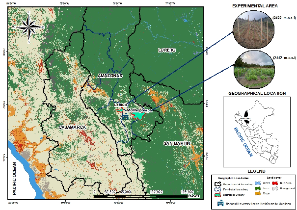

|  
Figure 1: Geographical location of the laboratory facilities and field experiment sites included in the study, showing the spatial distribution of both germination analyses and field evaluations located in the Amazonas region, Peru. |

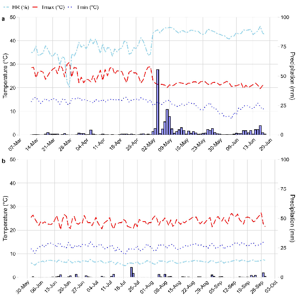

|  
Figure 2: Meteorological conditions of the field experimental sites during the 2024 growing season. (a) Climatic conditions for the Lamud site and (b) climatic conditions for the Molinopampa site. Data obtained from the Nasa Power Project (Prediction of Worldwide Energy Resources) based on satellite observations and atmospheric models. Precipitation is represented by blue bars. |

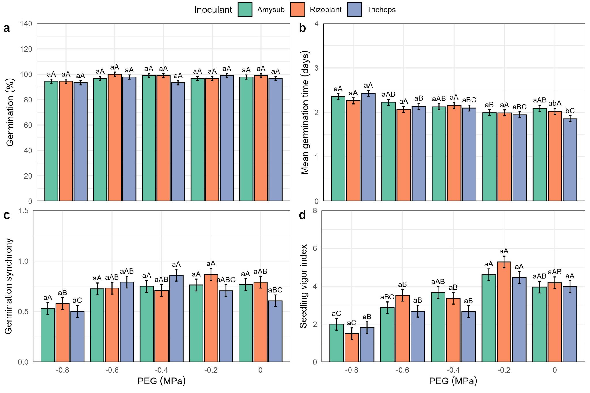

[output not shown]

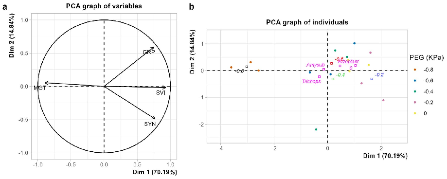

[output not shown]

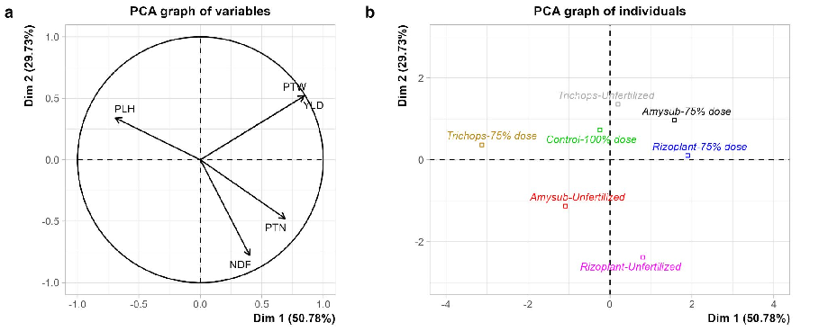

|  
Figure 6: Principal component analysis (PCA) of agronomic characteristics of pea plants grown from bio-inoculated seeds under different inoculant types and fertilization doses during the 2024 field season. (a) PCA of agronomic variables: plant height (PLH, cm), number of day to flowering (NDF, days), pod weight (PTW, g), pods per plant (PTN), and green pod yield (YLD, kg/ha). (b) PCA of individuals represented by treatment combinations of inoculant type (e.g., Amysub, Rizoplant, Trichops, and control) with different fertilization levels (100% dose, 75% dose, and unfertilized). |

Table 1: Commercial bio-inoculants used in the study and their active microorganisms with corresponding concentrations. |

| Bio-inoculant | Active microorganism | Concentration |
| --- | --- | --- |
| Amysub | *Bacillus subtilis, B. amyloliquefaciens* | ≥1 × 10⁹ CFU/g |
| Rizoplant | *Lactobacillus* spp. | 1.1 × 10⁵ CFU/mL |
|  | *Saccharomyces spp.* | 2.2 × 10⁴ CFU/mL |
|  | *Rhodopseudomonas spp.* | 2.3 × 10⁷ CFU/mL |
|  | *Streptomyces spp.* | 2.3 × 10⁵ CFU/mL |
|  | *Azotobacter spp.* | 3.0 × 10⁸ CFU/mL |
|  | *Azospirillum brasilense* | 6.5 × 10⁹ CFU/mL |
|  | *Bacillus spp.* | 6.0 × 10⁷ CFU/mL |
|  | *Trichoderma spp.* | 2.5 × 10⁷ CF/mL |
| Trichops | *Trichoderma harzianum, T. viride, T. asperellum* | >1.5 × 10¹⁰ conidia/g |

Table 2: Soil parameters at the two experimental sites according to soil test reports. |

| Parameter | Lamud | Molinopampa |
| --- | --- | --- |
| pH | 8.38 | 5.45 |
| Electrical conductivity | 0.16 dS/m | 0.34 dS/m |
| Phosphorus | 3.04 mg/kg | 16.61 mg/kg |
| Potassium | 338.89 mg/kg | 461.16 mg/kg |
| Carbon content | 2.32% | 2.80% |
| Organic matter | 3.99% | 4.83% |
| Nitrogen | 0.20% | 0.24% |

Table 3: Estimated marginal means (± SE) of plant height, flowering time, pod weight, number of pods per plant, and yield of pea as affected by inoculant type and fertilization level across study sites. |

| Site | Inoculant | Fertilization | Plant height (cm) | Flowering (days) | Pod weight (g) | Pods per plant | Yield (kg ha-1) |
| --- | --- | --- | --- | --- | --- | --- | --- |
| Lamud | Control | 100% dose | 43.04 ± 2.89 bB | 56.12 ± 0.56 bB | 9.32 ± 2.31 bB | 2.33 ± 0.51 bB | 1331.26 ± 329.43 bB |
|  | Amysub | 75% dose | 41.93 ± 2.89 bB | 56.70 ± 0.56 bB | 12.92 ± 2.31 bB | 2.33 ± 0.51 bB | 1846.05 ± 329.43 bB |
|  | Rizoplant | 75% dose | 42.04 ± 2.89 bB | 57.12 ± 0.56 bB | 12.53 ± 2.31 bB | 2.43 ± 0.51 bB | 1790.39 ± 329.43 bB |
|  | Trichops | 75% dose | 46.29 ± 2.89 bB | 56.12 ± 0.56 bB | 4.89 ± 2.31 bB | 2.10 ± 0.51 bB | 697.98 ± 329.43 bB |
|  | Amysub | Unfertilized | 42.75 ± 2.89 bB | 57.37 ± 0.56 bB | 6.68 ± 2.31 bB | 2.14 ± 0.51 bB | 953.76 ± 329.43 bB |
|  | Rizoplant | Unfertilized | 38.52 ± 2.89 bB | 57.29 ± 0.56 bB | 6.98 ± 2.31 bB | 2.51 ± 0.51 bB | 996.61 ± 329.43 bB |
|  | Trichops | Unfertilized | 39.77 ± 2.89 bB | 56.12 ± 0.56 bB | 10.70 ± 2.31 bB | 2.08 ± 0.51 bB | 1527.92 ± 329.43 bB |
| Molinopampa | Control | 100% dose | 105.09 ± 2.89 aA | 66.71 ± 0.56 aA | 65.83 ± 2.31 aA | 12.67 ± 0.51 aA | 9403.91 ± 329.43 aA |
|  | Amysub | 75% dose | 103.98 ± 2.89 aA | 67.30 ± 0.56 aA | 69.43 ± 2.31 aA | 12.67 ± 0.51 aA | 9918.70 ± 329.43 aA |
|  | Rizoplant | 75% dose | 104.09 ± 2.89 aA | 67.71 ± 0.56 aA | 69.04 ± 2.31 aA | 12.78 ± 0.51 aA | 9863.05 ± 329.43 aA |
|  | Trichops | 75% dose | 108.34 ± 2.89 aA | 66.71 ± 0.56 aA | 61.40 ± 2.31 aA | 12.44 ± 0.51 aA | 8770.64 ± 329.43 aA |
|  | Amysub | Unfertilized | 104.79 ± 2.89 aA | 67.96 ± 0.56 aA | 63.19 ± 2.31 aA | 12.49 ± 0.51 aA | 9026.41 ± 329.43 aA |
|  | Rizoplant | Unfertilized | 100.57 ± 2.89 aA | 67.88 ± 0.56 aA | 63.49 ± 2.31 aA | 12.86 ± 0.51 aA | 9069.27 ± 329.43 aA |
|  | Trichops | Unfertilized | 101.82 ± 2.89 aA | 66.71 ± 0.56 aA | 67.20 ± 2.31 aA | 12.42 ± 0.51 aA | 9600.58 ± 329.43 aA |